# 計量経済学

データの可視化I：図表の作成

矢内 勇生

2018-10-25（2018-10-28改訂）

## 準備

まず、今回使うパッケージを読み込む。インストール済みでないものは、`install.packages()` を使ってまずインストールする。

インストールしていないパッケージがある場合。

```r
install.packages("ggmap")
install.packages("knitr")
```

インストール済んだら、読み込む。

```r
library("tidyverse")
library("ggmap")
library("knitr")
```

## 分析結果を図表にする。

例として、 淺野・矢内 (2013, 2019刊行予定) で使われている衆議院総選挙の小選挙区候補者データセット [hr96-17.csv](https://git.io/fAnI2). を利用する。フォイルをダウンロードし、プロジェクト内の **data** フォルダ（他の場所がよければ自分で指定せよ）に保存しよう。

```r
download.file(url = "https://git.io/fAnI2",
             destfile = "data/hr96-17.csv")
```

CSVファイルは、`readr::read_csv()` で読み込むことができる。 このCSVファイルは、欠測値を “.” で記録しているので、引数 **na** でそのことをRに伝える。

```r
HR <- read_csv("data/hr96-17.csv", na = ".")
head(HR)    # 最初の6行を表示
```

```
## # A tibble: 6 x 17
##    year ku      kun status name  party party_code previous    wl voteshare
##   <int> <chr> <int>  <int> <chr> <chr>      <int>    <int> <int>     <dbl>
## 1  1996 aichi     1      1 KAWA… NFP            8        2     1      40
## 2  1996 aichi     1      2 IMAE… LDP            1        3     0      25.7
## 3  1996 aichi     1      1 SATO… DPJ            3        2     0      20.1
## 4  1996 aichi     1      0 IWAN… JCP            2        0     0      13.3
## 5  1996 aichi     1      0 ITO,… othe…        100        0     0       0.4
## 6  1996 aichi     1      0 YAMA… koku…         22        0     0       0.3
## # ... with 7 more variables: age <int>, nocand <int>, rank <int>,
## #   vote <int>, eligible <int>, turnout <dbl>, exp <int>
```

```r
tail(HR)    # 最後の6行を表示
```

```
## # A tibble: 6 x 17
##    year ku      kun status name  party party_code previous    wl voteshare
##   <int> <chr> <int>  <int> <chr> <chr>      <int>    <int> <int>     <dbl>
## 1  2017 yama…     1      1 NISH… othe…          7        0     0      2.95
## 2  2017 yama…     2      1 HORI… inde…         99        2     2     40.1
## 3  2017 yama…     2      0 NAGA… inde…         99        3     0     38.4
## 4  2017 yama…     2      0 KOBA… CDP           40        0     0     12.9
## 5  2017 yama…     2      0 IGET… POH           39        0     0      5.53
## 6  2017 yama…     2      0 OKUB… JCP            2        0     0      3.08
## # ... with 7 more variables: age <int>, nocand <int>, rank <int>,
## #   vote <int>, eligible <int>, turnout <dbl>, exp <int>
```

```r
glimpse(HR) # データの中身を確認するもう一つの方法
```

```
## Observations: 8,803
## Variables: 17
## $ year       <int> 1996, 1996, 1996, 1996, 1996, 1996, 1996, 1996, 199...
## $ ku         <chr> "aichi", "aichi", "aichi", "aichi", "aichi", "aichi...
## $ kun        <int> 1, 1, 1, 1, 1, 1, 1, 2, 2, 2, 2, 2, 2, 2, 2, 3, 3, ...
## $ status     <int> 1, 2, 1, 0, 0, 0, 0, 1, 2, 0, 0, 0, 0, 0, 0, 0, 1, ...
## $ name       <chr> "KAWAMURA, TAKASHI", "IMAEDA, NORIO", "SATO, TAISUK...
## $ party      <chr> "NFP", "LDP", "DPJ", "JCP", "others", "kokuminto", ...
## $ party_code <int> 8, 1, 3, 2, 100, 22, 99, 8, 1, 3, 2, 10, 100, 99, 2...
## $ previous   <int> 2, 3, 2, 0, 0, 0, 0, 1, 1, 0, 0, 0, 0, 0, 0, 1, 3, ...
## $ wl         <int> 1, 0, 0, 0, 0, 0, 0, 1, 0, 2, 0, 0, 0, 0, 0, 1, 0, ...
## $ voteshare  <dbl> 40.0, 25.7, 20.1, 13.3, 0.4, 0.3, 0.2, 32.9, 26.4, ...
## $ age        <int> 47, 72, 53, 43, 51, 51, 45, 51, 71, 30, 31, 44, 61,...
## $ nocand     <int> 7, 7, 7, 7, 7, 7, 7, 8, 8, 8, 8, 8, 8, 8, 8, 7, 7, ...
## $ rank       <int> 1, 2, 3, 4, 5, 6, 7, 1, 2, 3, 4, 5, 6, 7, 8, 1, 2, ...
## $ vote       <int> 66876, 42969, 33503, 22209, 616, 566, 312, 56101, 4...
## $ eligible   <int> 346774, 346774, 346774, 346774, 346774, 346774, 346...
## $ turnout    <dbl> 49.2, 49.2, 49.2, 49.2, 49.2, 49.2, 49.2, 51.8, 51....
## $ exp        <int> 9828097, 9311555, 9231284, 2177203, NA, NA, NA, 129...
```

これで、データセットがRに読み込まれた。HRという名前がこのデータフレームオブジェクトを参照している。

このデータセットは、複数の選挙結果を含んでいる。 どの年の選挙が含まれているか確認してみよう。 `table()` 関数で簡単な表ができる。 データフレームの中にあるそれぞれの変数にアクセスするために、`with()` 関数を一緒に使う。

```r
with(HR, table(year))
```

```
## year
## 1996 2000 2003 2005 2009 2012 2014 2017
## 1261 1199 1026  989 1139 1294  959  936
```

```r
# 次の行とやっていることは同じ
# table(HR$year)
```

8つの選挙に関するデータがあることがわかる。 2009年のデータだけ取り出して練習に使おう。 特定の条件を満たす観測値だけを取り出すには、 `dplyr::filter()` が使える。

```r
HR09 <- HR %>% filter(year == 2009)  # year == 2009 の行だけ選ぶ
with(HR09, table(year))
```

```
## year
## 2009
## 1139
```

ここでパイプ `%>%` はパイプの左側で評価された結果をパイプの右側に送り、右側の関数は受け取ったものを第1引数として利用する。したがって、`HR09 %>% filter (year == 2009)` の実行結果は`filter(HR09, year == 2009)` と全く同じである。 つまり、この例ではパイプを使う必要はまったくない。 しかし、将来的にはパイプを多用することになるので、簡単な例を使ってしっかり使い方を身につけよう。パイプを複数回使えば、複雑な変換を簡単に行うことが可能になる。パイプは、**magrittr** パッケージに含まれているが、**dplyr** を読み込むと自動的にmagrittrも読み込まれる。また、**tidyverse**を読み込むと、**dplyr** も読み込まれる。したがって、いつも**tidyverse** を読み込んでおいたほうが楽だ。

以下では、2009年の衆院選の結果だけが含まれた **HR09** を使って図表の作り方を学ぶ。

## Rで表を作る

2009年の衆院選データを使い、候補者の立場（**status**, 現職か元職か新人か）と選挙の勝敗 (**wl**) のクロス表を作る。

```r
(tbl_st_wl <- with(HR09, table(立場 = status, 結果 = wl)))
```

```
##     結果
## 立場   0   1   2
##    0 558  80  43
##    1 170 175  52
##    2  14  45   2
```

このままではどの数字がどのカテゴリを表しているかわかりにくいので、変数にラベルをつけよう。 ラベルをつけるために、変数の種類を整数 (integer) から因子 (factor) に変える。 二つの変数、*wl*と*status*にラベルをつけよう。 後で使うかもしれないので、全体のデータ（2009年以外を含む）にラベルをつけ、2009年の分を改めて取り出そう。

```r
HR <- HR %>%
    mutate(wl = factor(wl, levels = 0:2, labels = c("落選", "当選", "復活当選")),
           status = factor(status, levels = 0:2,
                           labels = c("新人", "現職", "元職")))
HR09 <- HR %>% filter(year == 2009)
```

先ほどと同じクロス表をもう一度作る。

```r
(tbl_st_wl <- with(HR09, table(立場 = status, 結果 = wl)))
```

```
##       結果
## 立場 落選 当選 復活当選
##   新人  558   80       43
##   現職  170  175       52
##   元職   14   45        2
```

データの内容を理解するためには、この表で十分かもしれない。 しかし、この表をそのまま論文（または課題）にコピペして使ってはいけない。 論文等で使うには、表の見た目を整える必要がある。

そこですぐに思いつくのは、MS Excel やLibreOffice Calc などに数字を入力して表を作る方法だろう。 しかし、**表計算ソフトに数字を手動で入力して表を作るのはやめたほうが良い。理由は2つある。第1に、入力ミスをする可能性がある。第2に、これがより重要だが、手入力は面倒（時間の無駄）である。** 幸い、Rには見栄えのよい表を作るための関数があるので、それを利用する。

Rマークダウンを使って文章を作るには、`knitr::kable()` が便利である。使い方は簡単で、以下のようにする。

```r
kable(tbl_st_wl, caption = "候補者の立場と選挙結果")
```

候補者の立場と選挙結果

|  | 落選 | 当選 | 復活当選 |
| --- | --- | --- | --- |
| 新人 | 558 | 80 | 43 |
| 現職 | 170 | 175 | 52 |
| 元職 | 14 | 45 | 2 |

表をCSVファイルに保存し、それをExcel やCalc などで開いて編集することもできる。 表をCSV ファイルに保存するには、`write.csv()` を使う。

```r
dir.create("tables")
write.csv(tbl_st_wl, file = 'tables/tbl-st-wl.csv')
```

プロジェクト内の tables ディレクトリ（フォルダ）に、“tbl-st-wl.csv” という名前のファイルが保存されているはずである。 これをExcel 等で開いて表を整形すれば、数値を手入力する手間は省ける。

## ggplot2 で図を作る

論文やプレゼンテーションで使う図は、**ggplot2** を使って作る。 **ggplot2** を使えば、Rで美しい図を作ることができる。 言うまでもなく、研究は見た目よりも中身（図が伝えるメッセージ）の方が大切である。 しかし、保持する情報が同じなら、美しい図の方が汚い図よりも望ましい。 汚い図を**解読する**より、美しい図を**愉しむ**方が多くの読者にとって楽である。 したがって、美しい図の方が、読者に情報を正しく伝達する可能性が高いと考えられる。 美しい図は、**ggplot2** を使わなくてもできる。しかし、ggplot2 を使わずに美しい図を作るには、熟練Rユーザになる必要がる。ggplot2 を使えば、ある程度美しい（少なくとも読むに耐える）図がデフォルトでできる。 つまり、ggplot2 は美しい図を作るための必要条件ではないが、（ほぼ）十分条件である（ただし、統計の使い方を正しく理解していることを前提とする）。

ggplot2は（も） [Hadley Wickham](http://hadley.nz) （日本の一部のRユーザは、「羽鳥先生」と呼んで崇拝している）によって開発された。

[figure not shown]

```r
ggimage(hadley)
```

使い方は、[ココ](http://ggplot2.org) に載っている。 より詳しい使い方は、Hadley Wickham. (2016). *ggplot2: Elegant Graphics for Data Analysis, 2nd ed.* (Springer) （[ココ](https://www.dropbox.com/s/0lap7tr7zoryyjk/ggplot2-book.pdf?dl=0) で入手できる）を参照されたい。

### ggplot2 入門

ggplot2 で図を作るときはいつも `ggplot2::ggplot()` 関数を使う。

`ggplot()` の第1引数には、データフレームを渡す。 したがって、ggplot2で図を作るためには、必要な変数を1つのデータフレームに保存する必要がある。

第2引数では、**aes** （*aesthetics*の略）を指定する（より正確には、mapping = aes(…)である）。 視覚化したい変数を**aes**で指定する。 例えば、2次元の図（散布図など）を作るときには、 横軸 $x$ と縦軸 $y$ の変数を指定する。 さらに、色 (color)、大きさ (size) などを指定して、図で表現する次元を増やすことができる。

次に、`ggplot()`で作られたオブジェクトに、グラフィックの層 (layer) を加える。 異なる種類の図は、異なる種類の層 (layer) で作る。 例えば、散布図を作りたいときは、`geom_point()` 層を加える。 ヒストグラムには `geom_histogram()`を使う。 これらの例が示すように、グラフィック層は **geom** （*geometry* の略）から始まる。 1つの図に複数のグラフィック層を重ねることもできる。

最後に、図に必要な他の要素、例えば、軸ラベルや凡例を加える（ただし、凡例は通常は自動的にできる）。

例として、選挙費用 (*exp*) と過去の当選回数 (*previous*) の散布図を作ってみよう。 まず、`ggplot()`関数でggplotオブジェクトを作る。 次に、`geom_point()`で散布図用の層 (layer) を加える。 最後に、`labs()` で軸ラベルとタイトルをつける（論文で使う図を作るときは、タイトルを空欄にして、図の**下**に番号つきのキャプションをつける。）

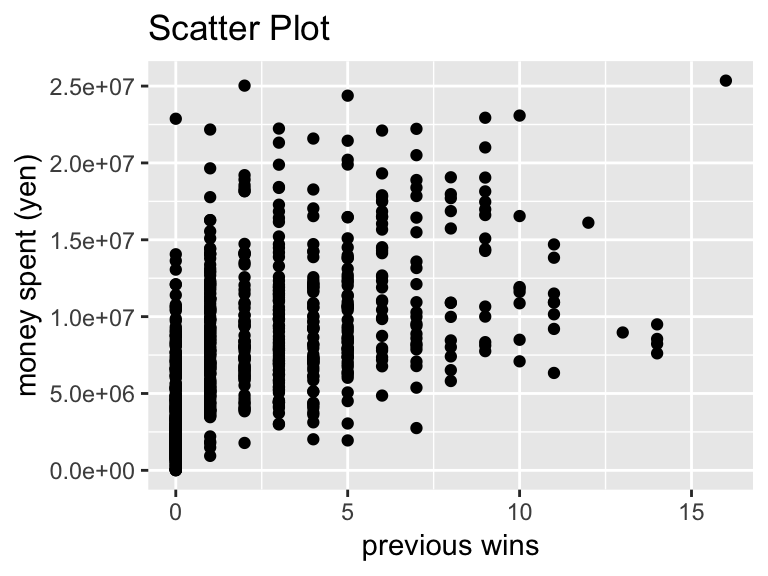

```r
# 1. ggplotオブジェクトを作る
scatter1 <- ggplot(HR09, aes(x = previous, y = exp))
# 2. 散布図の層 (layer) を加える
scatter1 <- scatter1 + geom_point()
# 3. 軸ラベルと図のタイトルを加える
scatter1 <- scatter1 + labs(x = "previous wins", y = "money spent (yen)",
                            title = "Scatter Plot")
# 4. 図を表示する
print(scatter1)
```

これで散布図ができた。表示以外のステップは、1度に実行することもできる。

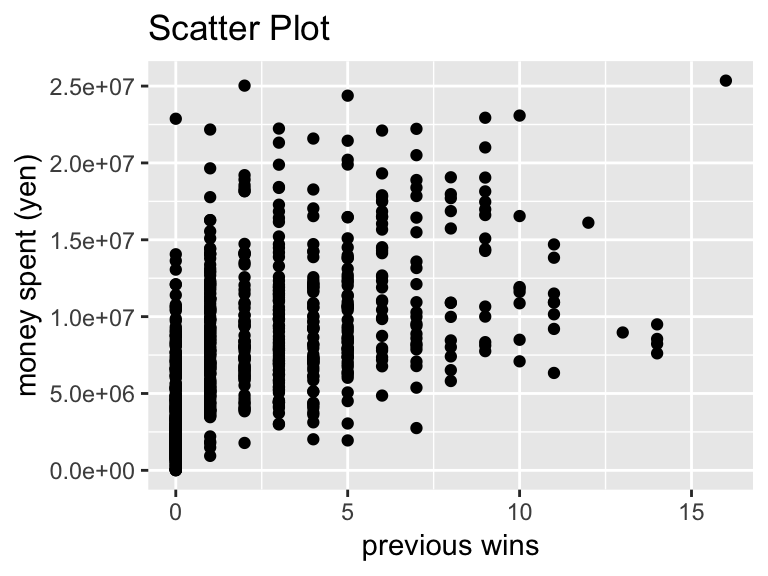

```r
scatter1 <- ggplot(HR09, aes(x = previous, y = exp)) +
    geom_point() +
    labs(x = "previous wins",
         y = "money spent (yen)",
         title = "Scatter Plot")
print(scatter1)
```

図を表示するときには、`print()`を使うが、これを使わずに単に `scatter1` としても通常は図が表示される。 しかし、安全のため、常に`print()`を使ったほうが良い（R Markdownを使う場合は特に）。

次に、選挙費用のヒストグラムを作ってみよう。 選挙費用はexpという変数が円単位で測定している。しかし、一円単位だと細かすぎるので、同じものを100万円単位で表現する expm という変数を新たに作ろう。

```r
HR09 <- mutate(HR09, expm = exp / 10^6)
```

通常のヒストグラムは1つの変数を図にするので、**aes** では **x** のみ指定すればよい。

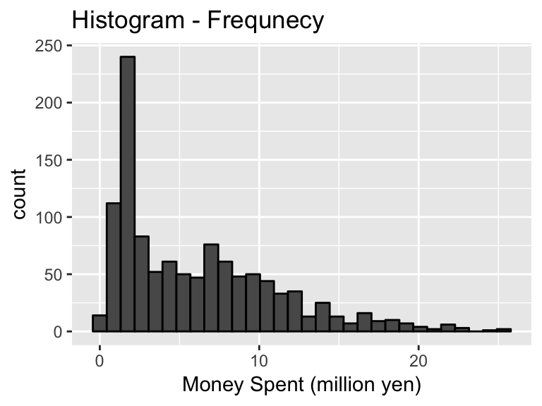

```r
histogram1 <- ggplot(HR09, aes(x = expm)) +
    geom_histogram(color = "black") +
    xlab('Money Spent (million yen)') +
    ggtitle('Histogram - Frequnecy')
print(histogram1)
```

このヒストグラムの縦軸は、「数（count; frequency, 頻度）」である。 縦軸を確率密度にしたいときは、次のようにする。

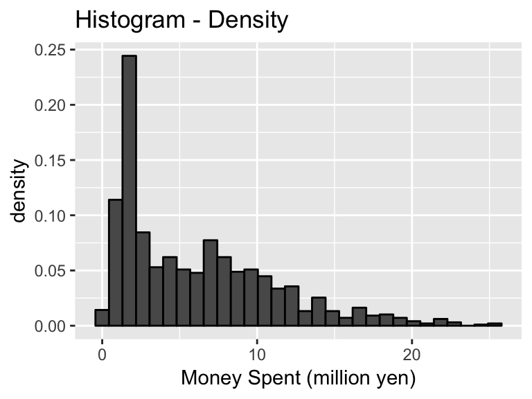

```r
histogram2 <- ggplot(HR09, aes(x = expm)) +
    geom_histogram(aes(y = ..density..), color = "black") +
    xlab('Money Spent (million yen)') +
    ggtitle('Histogram - Density')
print(histogram2)
```

このように、**aes** で `y = ..density..`をしてすればよい。 “density” の前後についているドットは、この “density” がデータフレームにもともとあった変数ではなく、`ggplot()` によって計算され、ggplot 内に保存されているものであることを示している。

ヒストグラムの一つひとつの棒（bin と呼ばれる）の幅を指定することもできる。200万円ごとに一つのビンにまとめたければ、次のようにする。

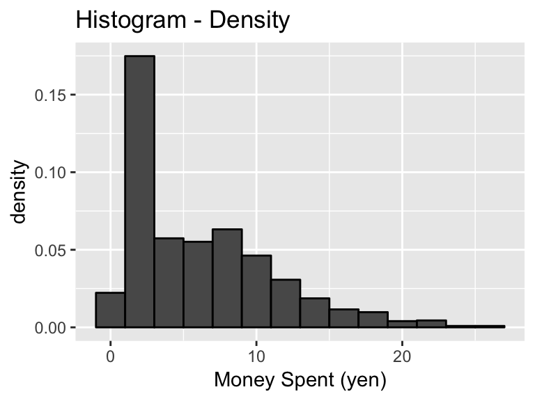

```r
histogram3 <- ggplot(HR09, aes(x = expm)) +
    geom_histogram(aes(y = ..density..),
                   binwidth = 2, color = "black") +
    xlab('Money Spent (yen)') +
    ggtitle('Histogram - Density')
print(histogram3)
```

次に、選挙費用の箱ひげ図を、過去の当選回数別に作って並べてみよう。

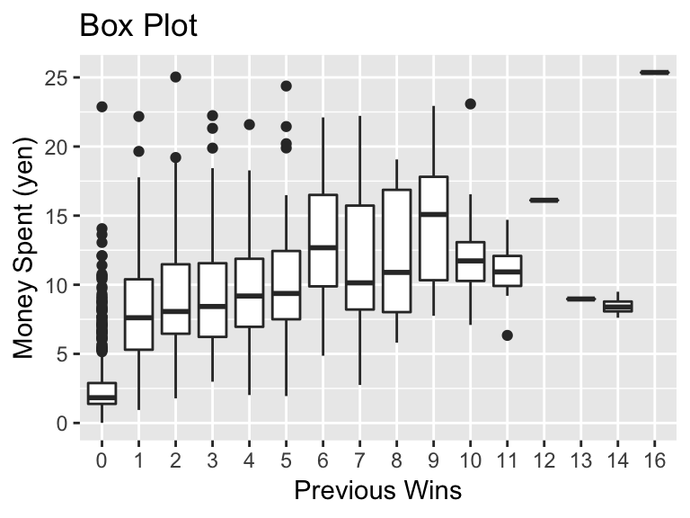

```r
box1 <- ggplot(HR09, aes(x = as.factor(previous), y = expm)) +
  geom_boxplot()
box1 <- box1 + labs(x = "Previous Wins", y = "Money Spent (yen)",
                    title = "Box Plot")
print(box1)
```

ここでは、 *previous* 変数を **aes** で指定するとき、`as.factor()` を使っている。 こうすることで、ggplotに previous がカテゴリー変数（したがって、箱ひげ図をグループ化できる）ことを伝えている。

続いて、得票率と選挙費用の散布図を作り、その上に回帰直線を重ね書きしてみよう。 回帰直線は、`geom_smooth(method = 'lm')` で描ける。

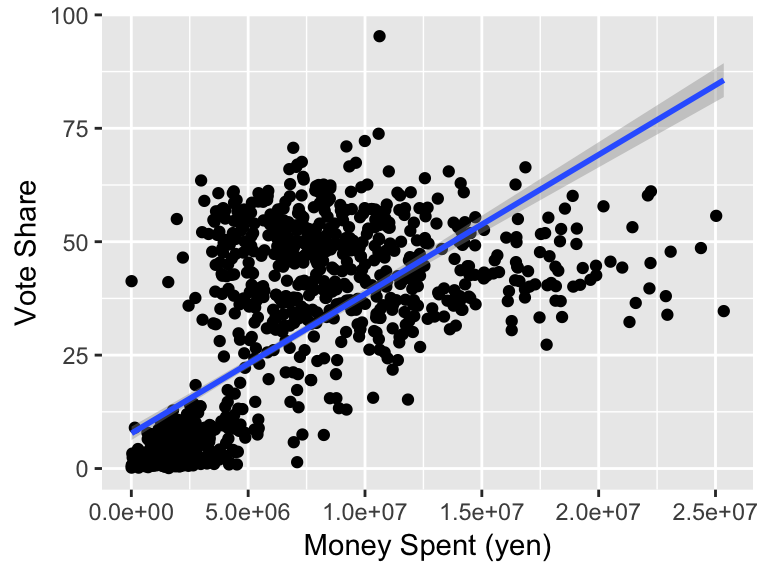

```r
scatter2 <- ggplot(HR09, aes(x = exp, y = voteshare))  +
  geom_point()
scatter2 <- scatter2 +
  labs(x = 'Money Spent (yen)', y = 'Vote Share')
scatter3 <- scatter2 +
  geom_smooth(method = 'lm')
print(scatter3)
```

`geom_smooth()` はデフォルトで95%信頼区間を直線の周りに示す。 他の信頼度を使いたいときは、**level** を指定する。 例えば、50%信頼区間に変えるには次のようにする。

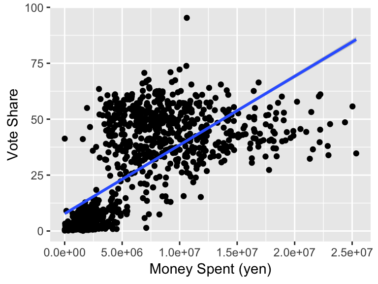

```r
scatter4 <- scatter2 +
  geom_smooth(method = 'lm', level = 0.5)
print(scatter4)
```

信頼区間を示したくないときは、**se = FALSE** とする。

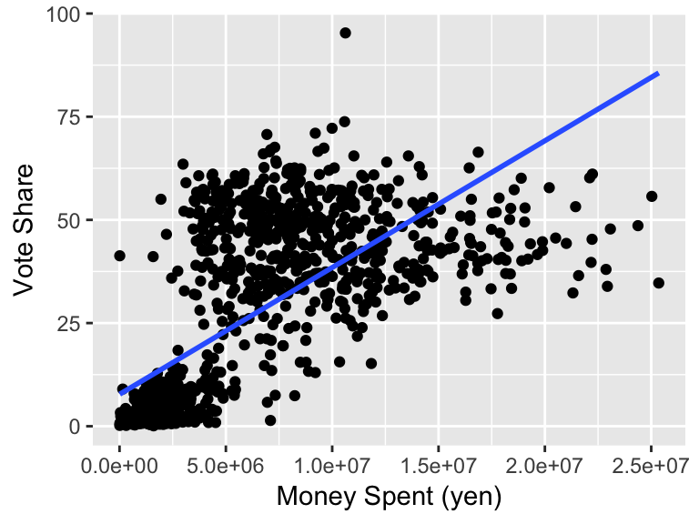

```r
scatter5 <- scatter2 + geom_smooth(method = 'lm', se = FALSE)
print(scatter5)
```

### ggplotで日本語を使う（Windowsユーザはこのセクションは飛ばしてよい）

通常の図で日本語を表示できるようにしただけでは、（Mac の）ggplot2で日本語を使うことはできない。 試しに、簡単な図を作ってみると、

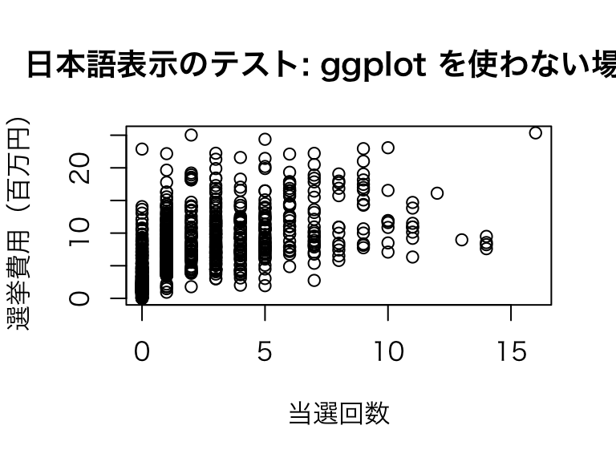

```r
plot(expm ~ previous, data = HR09,
     main = "日本語表示のテスト: ggplot を使わない場合",
     ylab = "選挙費用（百万円）", xlab = "当選回数")
```

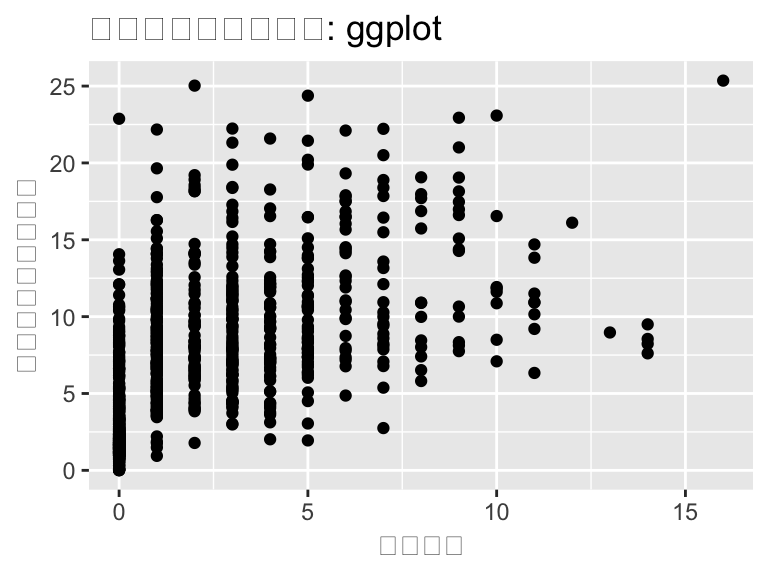

```r
test_jpn <- ggplot(HR09, aes(x = previous, y = expm)) +
  geom_point()
test_jpn <- test_jpn +
    labs(x = "当選回数", y = "選挙費用（百万円）",
         title = "日本語表示のテスト: ggplot")
print(test_jpn)
```

のように、ggplotで作った図では日本語が表示されない。

ggplot2で日本語を使う場合、ggplotのテーマで日本語を表示できるフォンとを選ぶ必要がある。 Macでヒラギノ角ゴシックを使うには、以下のようにテーマを設定する（もちろん、他に好みのフォントがあれば、違うフォントを選んでも良い）。**Windowsの場合は特に何もしなくてよい（はず）。

フォントに、10ポイントのヒラギノゴシックを指定する。

```r
theme_set(theme_gray(base_size = 10,
                     base_family = 'HiraginoSans-W3'))
# または
# theme_set(theme_gray(base_size = 10, base_family = "HiraKakuProN-W3"))
```

先ほどの図を表示してみよう。

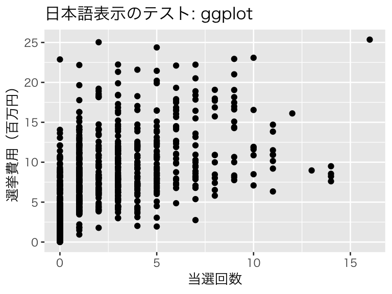

```r
print(test_jpn)
```

これでうまくいかないときは以下を試す。

```r
quartzFonts(HiraKaku = quartzFont(rep('Hiragino Sans W3', 4)))
theme_set(theme_gray(base_size = 10, base_family = 'HiraKaku'))
```

これで日本語が表示できるようになった。

### ggplot で作った図を保存する

#### 図を画像ファイル (PNG file) に保存する

ggplotで作った図は、 `ggplot2::ggsave()` で保存できる。 例えば、

```r
dir.create("figs")
ggsave(file = "figs/scatter-eg1.png", plot = scatter1, width = 6, height = 4.5)
```

で、scatter1 がfigs フォルダの中に ‘scatter-eg1.pn’ として保存される。 **plot** を指定しないと、最後に作った図が保存される。

図を保存するときは、実際に図として使う図の幅と高さを指定する。 幅 (width) が 6インチで 高さ (height) が 4.5インチ の図は、A4用紙を縦に置いた場合にはおおよそ半ページを占める。

#### 図をPDFファイルとして保存する。

論文用に図を保存するときは、PDF で保存したほうがよい。 Macでは、`quartz()` で **type = “pdf”** を指定すればPDFができる。

```r
quartz(file = "figs/scatter-eg1.pdf", family = "sans", type = "pdf",
       width = 6, height = 4.5)
print(scatter1)
dev.off()
```

`quartz()` で新しいグラフィックデバイスを開き、そこに`print()`で図を載せ、最後に `dev.off()`でデバイスを閉じている。 デバイスを閉じるのを忘れると、後で作った図もすべてこのデバイスに載ってしまうので、デバイスを閉じ忘れないように注意が必要である。 また、`quartz()`を使った図の保存はRマークダウンファイル上だとうまくいかないことがあるので、この部分はチャンクオプションで **eval=FALSE** を指定し、実行するときはコマンドをConsoleにコピー&ペースとした方がよい。

Windowsでは、（おそらく） `ggsave()` でPDFができる。

```r
ggsave(file = "scatter-eg1a.pdf", plot = scatter1)
```

これでうまくいかないときは、`pdf()` を次のように使う。

```r
pdf(file = "scatter-eg1b.pdf", family = "Japan1GothicBBB",
    width = 6, height = 4.5)
print(scatter1)
dev.off()
```

### ほんの少しだけ高度な使い方

#### グループごとにプロットの色やサイズ、形を変える

グループごとに色分け（サイズ分け、形分け）した図を作るには、**aes** でcolor (size, shape) にグループを表すカテゴリ変数を渡せばよい。 凡例は自動的にできる。

例として、議員が民主党 (DPJ) に所属していたかどうかで色分けしてみよう。 まず、民主党所属を表すダミー変数を作る。

```r
HR09 <- HR09 %>%
    mutate(dpj = as.numeric(party == "DPJ"),
           dpj = factor(dpj, labels = c("その他", "民主党")))
```

このダミー変数を使い、得票率と選挙費用の散布図を、民主党議員かどうかによって色分けして作ってみよう。

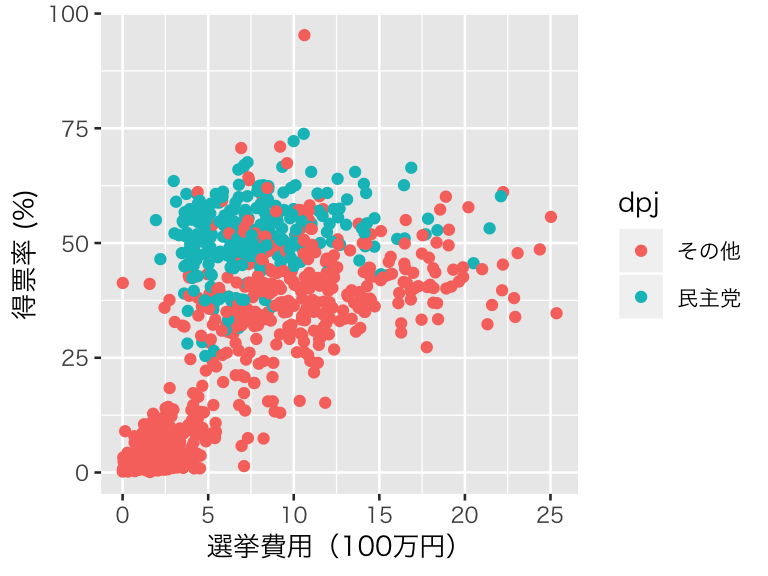

```r
sp_vs_ex <- ggplot(HR09, aes(x = expm, y = voteshare)) +
    labs(x = "選挙費用（100万円）", y = "得票率 (%)")
sp_vs_ex1 <- sp_vs_ex + geom_point(aes(color = dpj))
print(sp_vs_ex1)
```

カテゴリ変数で色分けされた凡例を調整したいときは、`scale_color_discrete()`. さらに、`guides()` で凡例の表示順を変えることができる。

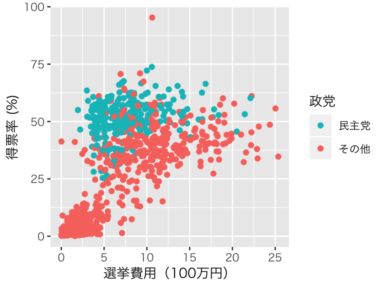

```r
sp_vs_ex2 <- sp_vs_ex1 +
  scale_color_discrete(name = "政党") +
  guides(color = guide_legend(reverse = TRUE))
print(sp_vs_ex2)
```

同じように、点の大きさを過去の当選回数によって変えてみよう。変数 *previous* を連続変数として扱うと、凡例は `scale_size_continuous()` で調整できる。

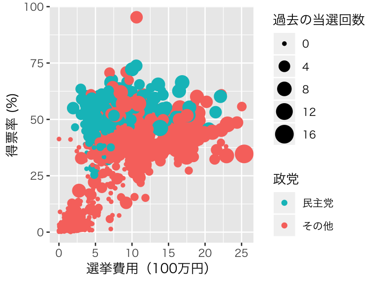

```r
sp_vs_ex3 <- sp_vs_ex +
  geom_point(aes(color = dpj, size = previous)) +
  scale_size_continuous(name = "過去の当選回数") +
  scale_color_discrete(name = "政党") +
  guides(color = guide_legend(reverse = TRUE))
print(sp_vs_ex3)
```

#### グループごとに作った図を並べる：Facetting

グループごとに分けて作った図を並べるときは、facetting （面刻み） という方法を使う ggplot2 には、2種類のfacetting が用意されている。 行グループと列グループによって並べる（グループ変数が2種類ある、または特定の方向に向かって並べたい）ときは、`facet_grid()`を使い、1つのグループ変数しか使わな（かつ、並べる方向は気にしない）ときは`facet_wrap()`を使う。

まず、`facet_grid()`の使い方を説明する。 例として、民主党に所属するかどうかでグループ分けをした選挙費用のヒストグラムを作る。 Facetting は `facet_grid(row_factor ~ column_factor)` で行う。 ここでは、列要素のみを指定する（つまり、図を横に並べる）。

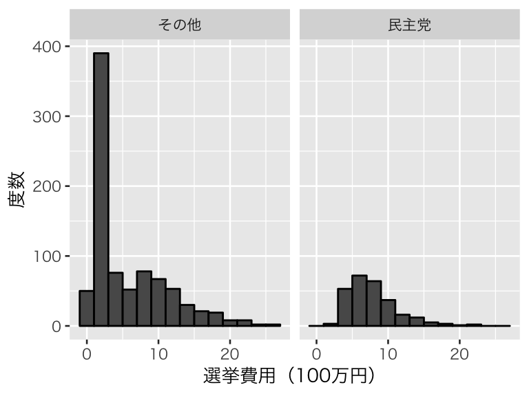

```r
hist_lab <- labs(x = "選挙費用（100万円）", y = "度数")
hist_exp_dpj <- ggplot(HR09, aes(x = expm)) +
  geom_histogram(color = "black", binwidth = 2)
hist_exp_dpj_1 <- hist_exp_dpj +
    facet_grid(. ~ dpj) +
    hist_lab
print(hist_exp_dpj_1)
```

縦に並べたいなら、次のようにする。

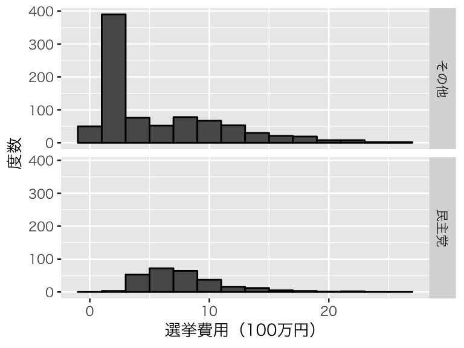

```r
hist_exp_dpj_2 <- hist_exp_dpj +
    facet_grid(dpj ~ .) +
    hist_lab
print(hist_exp_dpj_2)
```

二つのグループ変数（カテゴリ変数）を使って図をグリッド上に並べることもできる。 例えば、

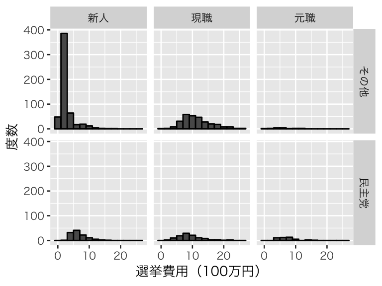

```r
hist_exp_dpj_st <- hist_exp_dpj +
  facet_grid(dpj ~ status) +
  hist_lab
print(hist_exp_dpj_st)
```

のように並べられる。

グループごとに図を作る範囲を変えるには、**scale = “free”** とする（横軸のみ可変にするには **scale = “free_x”**、縦軸のみ可変にするには **scale = “free_y”** とする）。

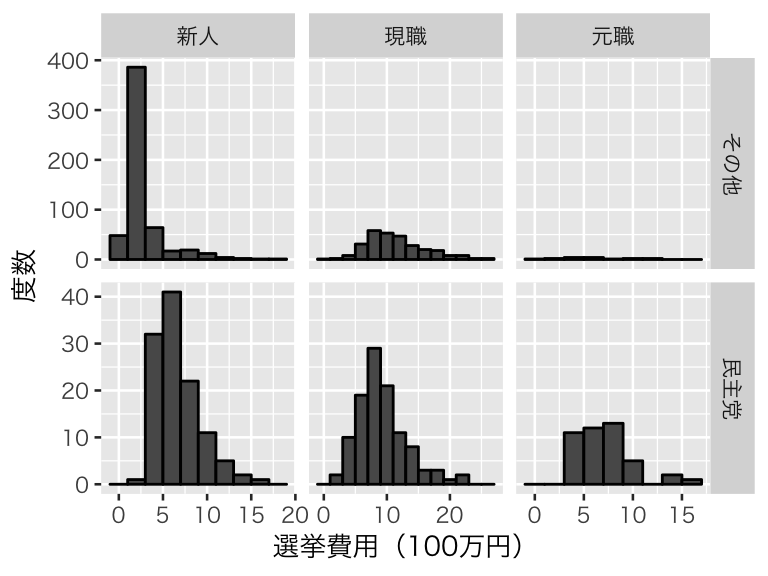

```r
hist_free_scale <- ggplot(HR09, aes(x = expm)) +
    geom_histogram(color = "black", binwidth = 2) +
    facet_grid(dpj ~ status, scale = "free") +
    hist_lab
print(hist_free_scale)
```

次に、 `facet_wrap()`の使い方を説明する。 この関数はグループ片数が1つだが、グループの数が多いために1行（あるいは1列）だけでは図を並べきれないときに便利である。 例として、選挙費用のヒストグラムを過去の当選回数別に作って並べてみよう。

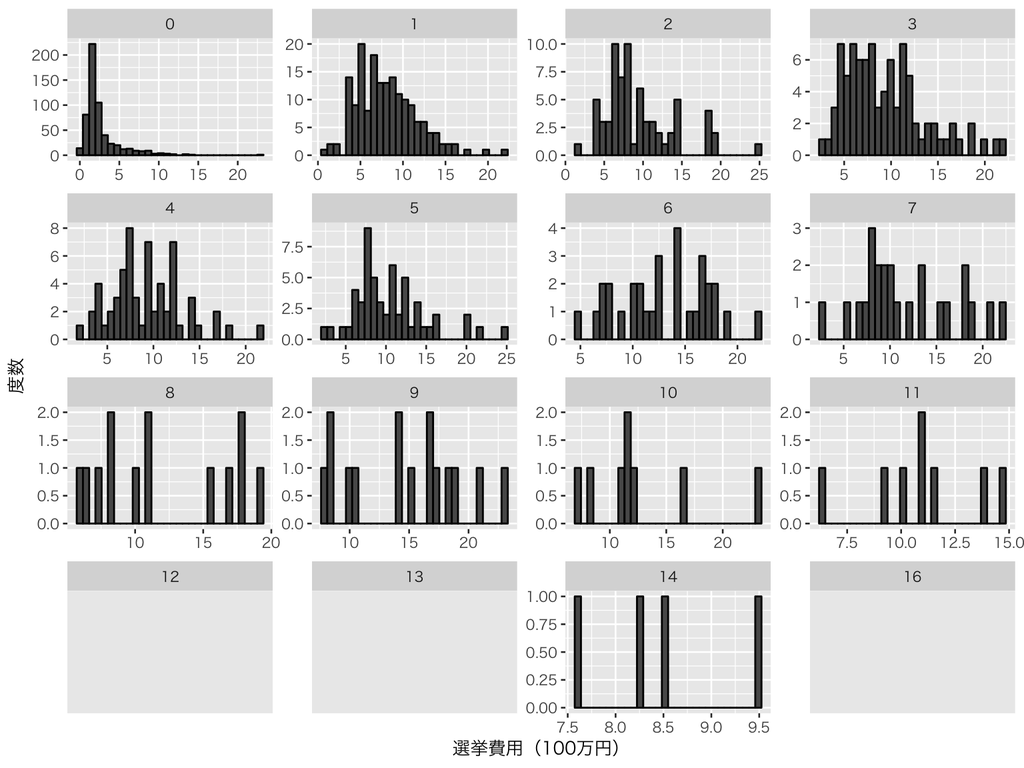

```r
hist_wins <- ggplot(HR09, aes(x = expm)) +
    geom_histogram(color = "black") +
    facet_wrap( ~ previous, scale = "free") +
    hist_lab
print(hist_wins)
```

授業の内容に戻る